# HW6

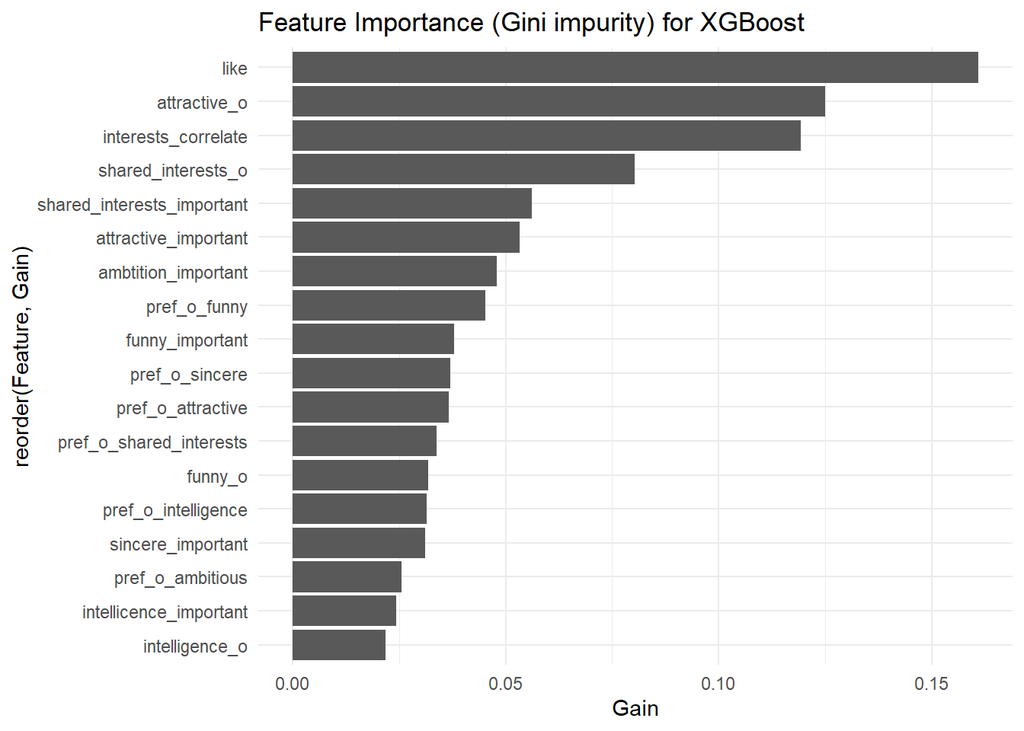

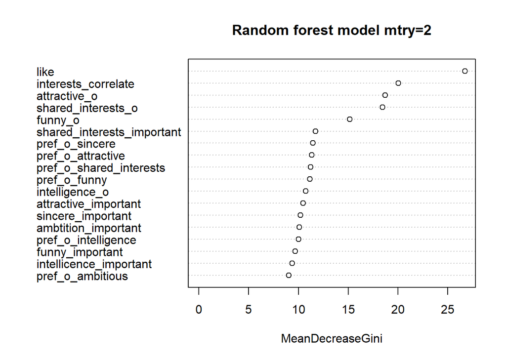

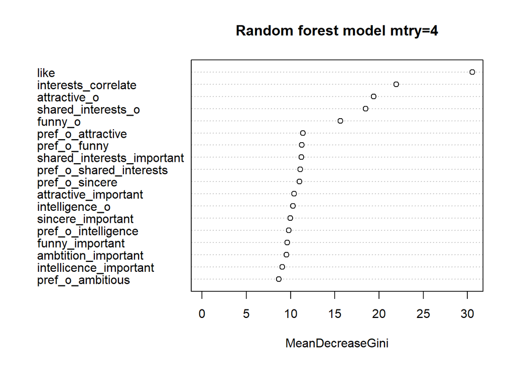

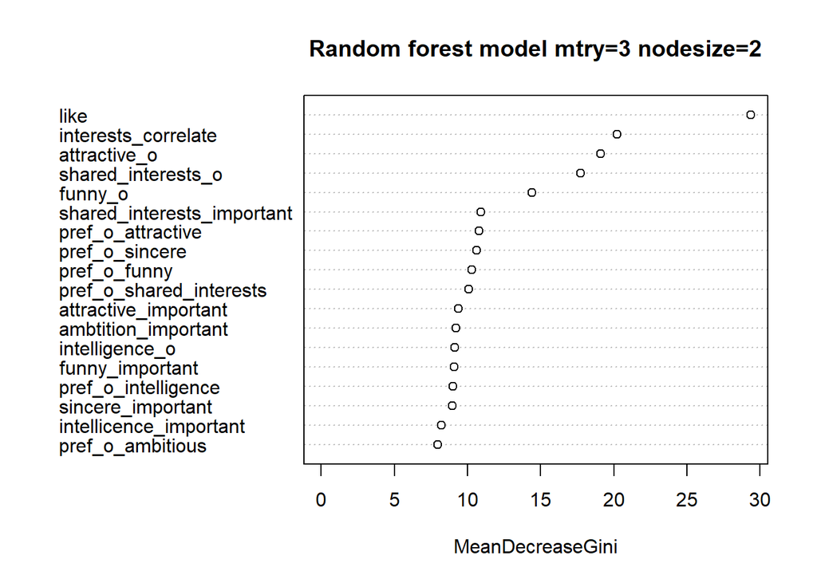

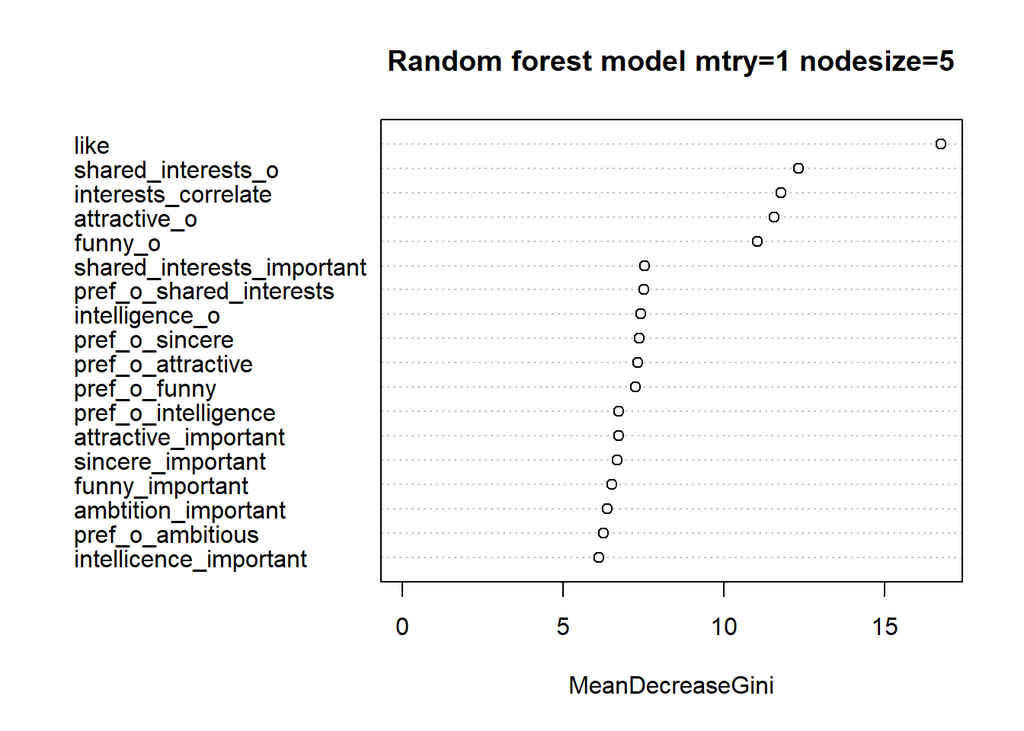

```r
explainers <- mapply(function(x, label){
    varImpPlot(x, main=paste0("Random forest ", label))
  },
                     rfs,
                     rf_model_labels,
                     SIMPLIFY=FALSE
                   )
```

### `DALEX` and `iml` does not posses implementation of Shapley values for whole dataset. Below is my try to solve this

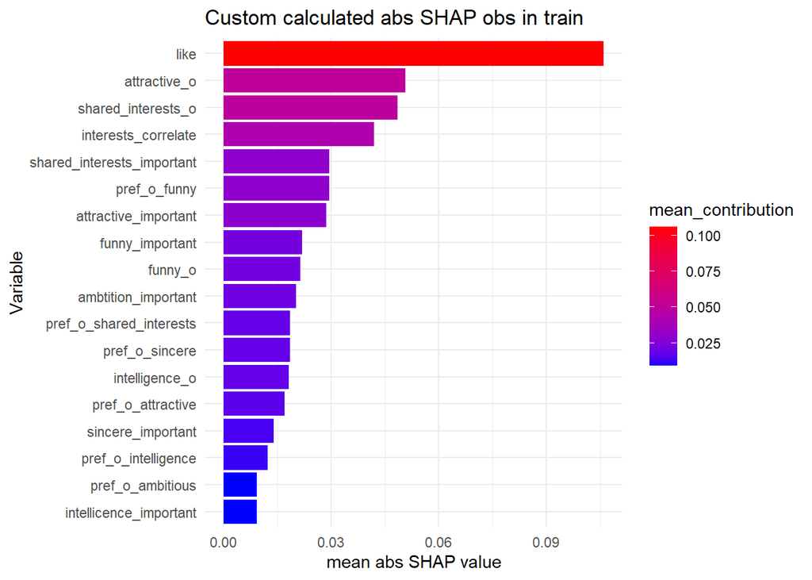

```r
for(i in seq(NROW(train))){
  if((i %% 10)==0){
    # print(sprintf("Iteration %s", i))
    if(i > 100){
      break
    }
  }
  new_obs <- as.matrix(train[i, 1:(NCOL(train)-1)]) # i-th observation
  shap <- predict_parts(explainer, type = "shap", new_observation=new_obs)
  shap_mean_ <- data.frame(shap) %>%
    group_by(variable_name) %>%
    summarise(mean_contribution = mean(abs(contribution), na.rm = TRUE)) %>% # abs
    arrange(variable_name)
  shap_mean_$mean_contribution = abs(shap_mean_$mean_contribution)
  if(i==1){
    shap_mean = shap_mean_
  }else{
    shap_mean$mean_contribution = shap_mean$mean_contribution + shap_mean_$mean_contribution
  }
}
shap_mean$mean_contribution = shap_mean$mean_contribution / i
shap_mean <- shap_mean %>%
  arrange(desc(mean_contribution))

ggplot(shap_mean, aes(x = reorder(variable_name, mean_contribution),
                      y = mean_contribution)) +
  geom_bar(stat = "identity", aes(fill = mean_contribution)) +
  coord_flip() +
  ggtitle("Custom calculated abs SHAP obs in train") +
  labs(x = "Variable", y = "mean abs SHAP value") +
  theme_minimal() +
  scale_fill_gradient(low = "blue", high = "red")
```

- Results given by SHAP and Gini impurity based feature importance (below) are similar - top two variables are the same, third and forth are flipped. In case of SHAP explanation `like` variable seems to be more important
- I’ve supposed that`like` is more or less correlated then rest of variables but Spearman correlation shows average level of `like` variable with top and mean correlation with rest of variables.

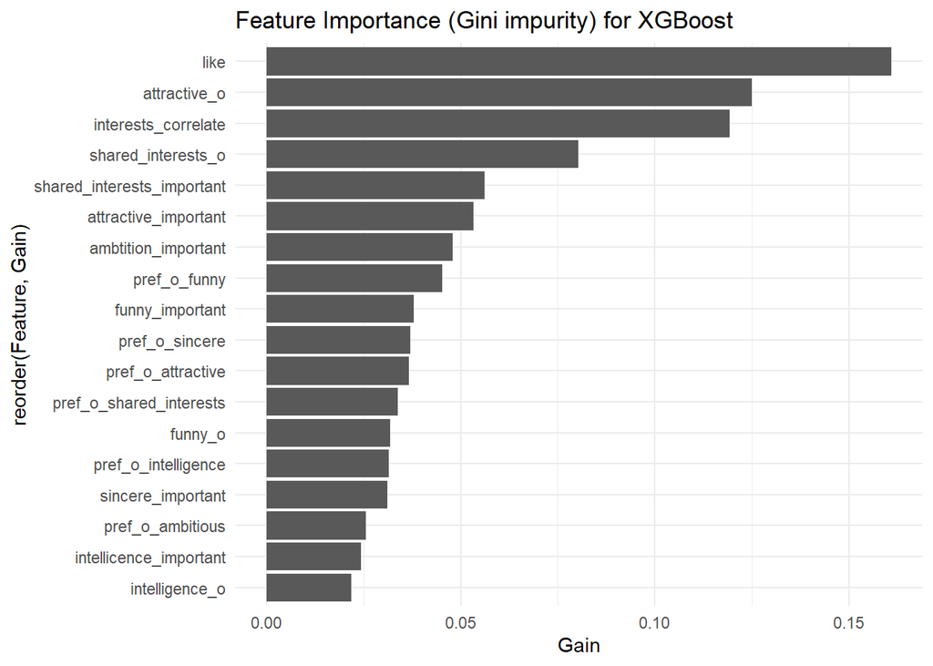

```r
ggplot(data = importance_scores) +
  geom_bar(aes(x = Gain, y = reorder(Feature, Gain)), stat = "identity") +
  labs(title = "Feature Importance (Gini impurity) for XGBoost") +
  theme_minimal()
```

- correlation of `like` with other variables are not different then between other variables

```r
vars_ =  c("like", "attractive_o", "interests_correlate", "shared_interests_o")
print(cor(train[vars_], method = "spearman") %>% round(2))
```

```
##                     like attractive_o interests_correlate shared_interests_o
## like                1.00         0.14                0.11               0.16
## attractive_o        0.14         1.00                0.01               0.50
## interests_correlate 0.11         0.01                1.00               0.05
## shared_interests_o  0.16         0.50                0.05               1.00
```

```r
cor(train, method = "spearman") %>%
  data.frame -> df_cor
df_cor %>%
  abs %>%
  rowMeans() %>%
  round(2) %>%
  sort %>%
  data.frame(absolute_mean_spearman=.) -> df

print(df, quote = FALSE, row.names = T)
```

```
##                            absolute_mean_spearman
## sincere_important                            0.11
## pref_o_sincere                               0.12
## pref_o_funny                                 0.12
## intellicence_important                       0.12
## pref_o_intelligence                          0.13
## pref_o_shared_interests                      0.13
## funny_important                              0.13
## shared_interests_important                   0.13
## interests_correlate                          0.13
## like                                         0.13
## pref_o_ambitious                             0.15
## ambtition_important                          0.15
## TARGET                                       0.15
## intelligence_o                               0.17
## pref_o_attractive                            0.18
## shared_interests_o                           0.18
## attractive_o                                 0.19
## attractive_important                         0.19
## funny_o                                      0.20
```

- correlation of `like` is high but not much higher then `attractive_o`

```r
df_cor["TARGET"] %>% round(2) -> df_cor
names(df_cor)[0] <- "correlation with TARGET var"
print(df_cor)
```

```
##                            TARGET
## pref_o_attractive           -0.05
## pref_o_sincere              -0.03
## pref_o_intelligence         -0.02
## pref_o_funny                 0.06
## pref_o_ambitious            -0.01
## pref_o_shared_interests      0.02
## attractive_o                 0.31
## intelligence_o               0.17
## funny_o                      0.28
## shared_interests_o           0.29
## attractive_important        -0.09
## sincere_important            0.00
## intellicence_important       0.01
## funny_important              0.07
## ambtition_important          0.02
## shared_interests_important   0.05
## interests_correlate          0.06
## like                         0.35
## TARGET                       1.00
```

### Number of levels in each variable

```r
for(name in names(train)){
  value <- nlevels(factor(train[[name]]))
  print(c(name, value))
}
```

```
## [1] "pref_o_attractive" "20"
## [1] "pref_o_sincere" "21"
## [1] "pref_o_intelligence" "19"
## [1] "pref_o_funny" "19"
## [1] "pref_o_ambitious" "20"
## [1] "pref_o_shared_interests" "17"
## [1] "attractive_o" "12"
## [1] "intelligence_o" "13"
## [1] "funny_o" "12"
## [1] "shared_interests_o" "13"
## [1] "attractive_important" "17"
## [1] "sincere_important" "17"
## [1] "intellicence_important" "15"
## [1] "funny_important" "16"
## [1] "ambtition_important" "16"
## [1] "shared_interests_important" "12"
## [1] "interests_correlate" "135"
## [1] "like" "14"
## [1] "TARGET" "2"
```